# Plot model contrasts

Plotting all linear model effects and contrasts

```r
knitr::opts_chunk$set(fig.height = 6, fig.width = 6)

library(erikmisc)
```

# 1 Plotting model contrasts

The `e_plot_model_contrasts()` function is a wrapper for `emmeans::emmeans()`. It automates plotting all of the model effects and annotating the plots with estimates and contrasts. Now it is (almost) effortless to interpret a linear model output.

This has been tested for `lm()` (fixed-effects model) and `lme4::lmer` (mixed fixed- and random-effects model).

## 1.1 Data

The data variables are labelled and those will be used for plots.

```r
str(dat_mtcars_e)
```

```
#> tibble [32 × 12] (S3: tbl_df/tbl/data.frame)
#>  $ model: chr [1:32] "Mazda RX4" "Mazda RX4 Wag" "Datsun 710" "Hornet 4 Drive" ...
#>   ..- attr(*, "label")= chr "Model"
#>  $ mpg  : num [1:32] 21 21 22.8 21.4 18.7 18.1 14.3 24.4 22.8 19.2 ...
#>   ..- attr(*, "label")= chr "Miles/(US) gallon"
#>  $ cyl  : Factor w/ 3 levels "four","six","eight": 2 2 1 2 3 2 3 1 1 2 ...
#>   ..- attr(*, "label")= chr "Number of cylinders"
#>  $ disp : num [1:32] 160 160 108 258 360 ...
#>   ..- attr(*, "label")= chr "Displacement (cu.in.)"
#>  $ hp   : num [1:32] 110 110 93 110 175 105 245 62 95 123 ...
#>   ..- attr(*, "label")= chr "Gross horsepower"
#>  $ drat : num [1:32] 3.9 3.9 3.85 3.08 3.15 2.76 3.21 3.69 3.92 3.92 ...
#>   ..- attr(*, "label")= chr "Rear axle ratio"
#>  $ wt   : num [1:32] 2.62 2.88 2.32 3.21 3.44 ...
#>   ..- attr(*, "label")= chr "Weight (1000 lbs)"
#>  $ qsec : num [1:32] 16.5 17 18.6 19.4 17 ...
#>   ..- attr(*, "label")= chr "1/4 mile time"
#>  $ vs   : Factor w/ 2 levels "V-shaped","straight": 1 1 2 2 1 2 1 2 2 2 ...
#>   ..- attr(*, "label")= chr "Engine"
#>  $ am   : Factor w/ 2 levels "automatic","manual": 2 2 2 1 1 1 1 1 1 1 ...
#>   ..- attr(*, "label")= chr "Transmission"
#>  $ gear : num [1:32] 4 4 4 3 3 3 3 4 4 4 ...
#>   ..- attr(*, "label")= chr "Number of forward gears"
#>  $ carb : num [1:32] 4 4 1 1 2 1 4 2 2 4 ...
#>   ..- attr(*, "label")= chr "Number of carburetors"
```

## 1.2 Fit model

This model is specifically chosen to have numeric and categorical main effects, and each type of two-way interaction (cat:cat, cat:num, num:num), as well as some categories that were not estimable. “Statistical significance” and “model fit” are not concerns in this demonstration.

```r
 # Set specific model with some interactions
form_model <-
  mpg ~ cyl + disp + hp + wt + vs + am + cyl:vs + disp:hp + hp:vs

fit <-
  lm(
    formula = form_model
  , data    = dat_mtcars_e
  )

car::Anova(
    fit
  , type = 3
  , singular.ok = TRUE
  )
```

```
#> Note: model has aliased coefficients
#>       sums of squares computed by model comparison
#> Anova Table (Type III tests)
#>
#> Response: mpg
#>            Sum Sq Df F values  Pr(>F)
#> cyl         2.701  2   0.2312 0.79554
#> disp        1.137  1   0.1947 0.66357
#> hp          6.223  1   1.0655 0.31371
#> wt         31.610  1   5.4123 0.03009 *
#> vs          5.080  1   0.8698 0.36160
#> am          3.593  1   0.6152 0.44159
#> cyl:vs      1.746  1   0.2989 0.59032
#> disp:hp     1.930  1   0.3305 0.57150
#> hp:vs       5.004  1   0.8568 0.36515
#> Residuals 122.648 21
#> ---
#> Signif. codes:  0 '***' 0.001 '**' 0.01 '*' 0.05 '.' 0.1 ' ' 1
```

```r
summary(fit)
```

```
#>
#> Call:
#> lm(formula = form_model, data = dat_mtcars_e)
#>
#> Residuals:
#>     Min      1Q  Median      3Q     Max
#> -3.2634 -1.6094 -0.3633  1.3947  3.8193
#>
#> Coefficients: (1 not defined because of singularities)
#>                       Estimate Std. Error t value Pr(>|t|)
#> (Intercept)          3.598e+01  8.628e+00   4.170 0.000433 ***
#> cylsix              -1.967e+00  3.313e+00  -0.594 0.559012
#> cyleight            -8.898e-01  4.369e+00  -0.204 0.840561
#> disp                -1.501e-02  3.403e-02  -0.441 0.663566
#> hp                  -5.193e-02  5.031e-02  -1.032 0.313707
#> wt                  -2.821e+00  1.213e+00  -2.326 0.030086 *
#> vsstraight           5.149e+00  5.521e+00   0.933 0.361603
#> ammanual             1.521e+00  1.939e+00   0.784 0.441592
#> cylsix:vsstraight    1.970e+00  3.603e+00   0.547 0.590322
#> cyleight:vsstraight         NA         NA      NA       NA
#> disp:hp              9.752e-05  1.696e-04   0.575 0.571500
#> hp:vsstraight       -4.915e-02  5.310e-02  -0.926 0.365152
#> ---
#> Signif. codes:  0 '***' 0.001 '**' 0.01 '*' 0.05 '.' 0.1 ' ' 1
#>
#> Residual standard error: 2.417 on 21 degrees of freedom
#> Multiple R-squared:  0.8911, Adjusted R-squared:  0.8392
#> F-statistic: 17.18 on 10 and 21 DF,  p-value: 5.984e-08
```

## 1.3 Plotting model effects and contrasts

### 1.3.1 Defaults

See the help `?e_plot_model_contrasts` for the method defaults. I’m choosing to not print the output (default) while the function runs so that we can examine the separate lists in the output.

```r
fit_contrasts <-
  e_plot_model_contrasts(
    fit                = fit
  , dat_cont           = dat_mtcars_e
  , sw_print           = FALSE
  )
```

```
#> e_plot_model_contrasts: Skipping "cyl" since involved in interactions.
#> e_plot_model_contrasts: Skipping "disp" since involved in interactions.
#> e_plot_model_contrasts: Skipping "hp" since involved in interactions.
#> e_plot_model_contrasts: Skipping "vs" since involved in interactions.
#> Warning: Comparison discrepancy in group "straight", four - six:
#>     Target overlap = 0.9995, overlap on graph = -101.2269
#> Warning: Comparison discrepancy in group "straight", four - six:
#>     Target overlap = 0.9995, overlap on graph = -104.1881
#> I bet you wanted to call this with just object[[1]] - use '[[]]' or which' if I'm wrong.
#> See '? emm_list' for more information
```

The output contains lists for tables, plots, and text.

```r
fit_contrasts %>% names()
```

```
#> [1] "tables" "plots"  "text"
```

#### 1.3.1.1 tables

The `tables` are give the estimates (`$est`) and contrasts (`$cont`) for each effect in the model not involved with an interaction (argument `sw_marginal_even_if_interaction` can include all main effects).

```r
fit_contrasts$tables  # to print tables
```

```
#> $wt
#> $wt$est
#>    wt wt.trend   SE df lower.CL upper.CL
#>  3.22    -2.82 1.21 21    -5.34   -0.299
#>
#> Results are averaged over the levels of: cyl, vs, am
#> Confidence level used: 0.95
#>
#>
#> $am
#> $am$est
#>  am        emmean   SE df lower.CL upper.CL
#>  automatic   17.5 1.25 21     14.5     20.5
#>  manual      19.0 1.77 21     14.7     23.3
#>
#> Results are averaged over the levels of: cyl, vs
#> Confidence level used: 0.95
#> Conf-level adjustment: sidak method for 2 estimates
#>
#> $am$cont
#>  contrast           estimate   SE df t.ratio p.value
#>  automatic - manual    -1.52 1.94 21  -0.784  0.4416
#>
#> Results are averaged over the levels of: cyl, vs
#>
#>
#> $`cyl:vs`
#> $`cyl:vs`$est
#> cyl = four:
#>  vs       emmean   SE df lower.CL upper.CL
#>  V-shaped   19.9 3.53 21    11.39     28.4
#>  straight   17.8 2.73 21    11.24     24.4
#>
#> cyl = six:
#>  vs       emmean   SE df lower.CL upper.CL
#>  V-shaped   17.9 1.82 21    13.54     22.3
#>  straight   17.8 1.91 21    13.23     22.4
#>
#> cyl = eight:
#>  vs       emmean   SE df lower.CL upper.CL
```

[output cut: 22 more lines]

```
#>
#> $`hp:vs`
#> $`hp:vs`$est
#>  vs       hp.trend     SE df lower.CL upper.CL
#>  V-shaped  -0.0294 0.0177 21  -0.0662  0.00732
#>  straight  -0.0786 0.0449 21  -0.1721  0.01490
#>
#> Results are averaged over the levels of: cyl, am
#> Confidence level used: 0.95
#>
#> $`hp:vs`$cont
#>  contrast              estimate     SE df t.ratio p.value
#>  (V-shaped) - straight   0.0491 0.0531 21   0.926  0.3652
#>
#> Results are averaged over the levels of: cyl, am
```

#### 1.3.1.2 text

The `text` of the tables are written in a form that can be copy/pasted into a report and worked into sentences.

```r
fit_contrasts$text    # to print caption text
```

```
#> $wt
#> $wt[[1]]
#> [1] "Estimate: (at mean = 3.22): -2.82, 95% CI: (-5.34, -0.299)"
#> [2] "Tables: Results are averaged over the levels of: cyl, vs, am"
#> [3] "Plot: Results are averaged over the levels of: cyl, disp, hp, vs, am"
#>
#> $wt[[2]]
#> [1] "Estimate: (at mean = 3.22): -2.82, 95% CI: (-5.34, -0.299)"
#> [2] "Tables: Confidence level used: 0.95"
#> [3] "Plot: Results are averaged over the levels of: cyl, disp, hp, vs, am"
#>
#>
#> $am
#> $am[[1]]
#> [1] "Estimate: automatic = 17.5, 95% CI: (14.5, 20.5)"
#> [2] "Estimate: manual = 19, 95% CI: (14.7, 23.3)"
#> [3] "Contrast: automatic - manual = -1.52, p-value = 0.4416"
#> [4] "Results are averaged over the levels of: cyl, vs"
#>
#>
#> $`cyl:vs`
#> $`cyl:vs`[[1]]
#> $`cyl:vs`[[1]][[1]]
#>  [1] "vs = V-shaped:"
#>  [2] "Estimate: four = 19.9, 95% CI: (10.7, 29)"
#>  [3] "Estimate: six = 17.9, 95% CI: (13.2, 22.6)"
#>  [4] "Estimate: eight = 19, 95% CI: (14.7, 23.3)"
#>  [5] "vs = straight:"
#>  [6] "Estimate: four = 17.8, 95% CI: (10.7, 24.9)"
#>  [7] "Estimate: six = 17.8, 95% CI: (12.9, 22.8)"
#>  [8] "Estimate: eight = 16.9, 95% CI: (5.17, 28.7)"
#>  [9] ""
#> [10] "vs = V-shaped:"
#> [11] "Contrast: four - six = 1.97, p-value = 0.9142"
#> [12] "Contrast: four - eight = 0.89, p-value = 0.9959"
#> [13] "Contrast: six - eight = -1.08, p-value = 0.9789"
#> [14] "vs = straight:"
#> [15] "Contrast: four - six = -0.00314, p-value = 1"
#> [16] "Contrast: four - eight = NA, p-value = NA"
#> [17] "Contrast: six - eight = NA, p-value = NA"
```

[output cut: 47 more lines]

```
#> $`hp:vs`
#> $`hp:vs`[[1]]
#> $`hp:vs`[[1]][[1]]
#> [1] "Estimate: V-shaped = -0.0294, 95% CI: (-0.0662, 0.00732)"
#> [2] "Estimate: straight = -0.0786, 95% CI: (-0.172, 0.0149)"
#> [3] "Contrast: (V-shaped) - straight = 0.0491, p-value = 0.3652"
#> [4] "Results are averaged over the levels of: cyl, am"
#>
#>
#> $`hp:vs`[[2]]
#> $`hp:vs`[[2]][[1]]
#> [1] "Estimate: V-shaped = -0.0294, 95% CI: (-0.0662, 0.00732)"
#> [2] "Estimate: straight = -0.0786, 95% CI: (-0.172, 0.0149)"
#> [3] "Contrast: (V-shaped) - straight = 0.0491, p-value = 0.3652"
#> [4] "Results are averaged over the levels of: cyl, am"
```

#### 1.3.1.3 plots

The `plots` illustrate the effects with labelled plots and the `text` in the caption for a single complete result.

From the help:

```
Plot interpretation:
This EMM plot (Estimated Marginal Means, aka Least-Squares Means) is only
available when conditioning on one variable. The blue bars are confidence
intervals for the EMMs; don't ever use confidence intervals for EMMs to perform
comparisons --- they can be very misleading. The red arrows are for the
comparisons between means; the degree to which the "comparison arrows" overlap
reflects as much as possible the significance of the comparison of the two
estimates. If an arrow from one mean overlaps an arrow from another group, the
difference is not significant, based on the adjust setting (which defaults to
"tukey").
```

For two-way interactions, both directions of conditioning are plotted: `var1|var2` and `var2|var1`. Furthermore, each plot is made separately and given in a side-by-side or above-below orientation. Use `ggsave()` for a specific plot object and choose a good `width` and `height` to make it look beautiful.

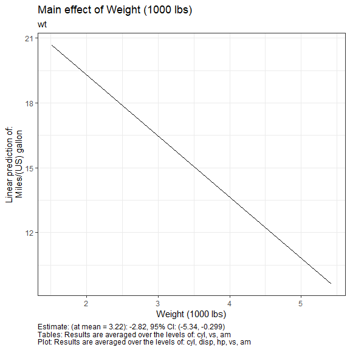

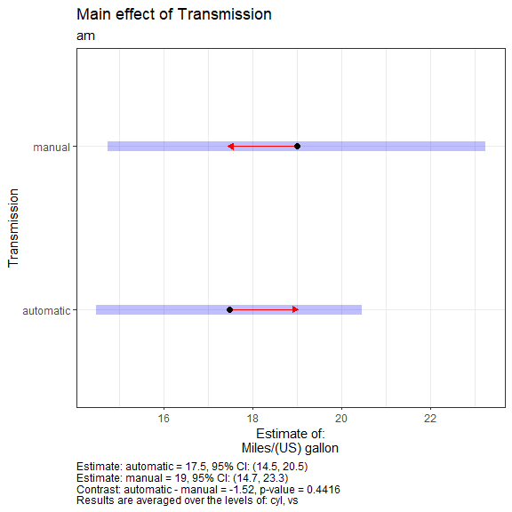

```
#>
#> $`cyl:vs`
#> $`cyl:vs`[[1]]
```

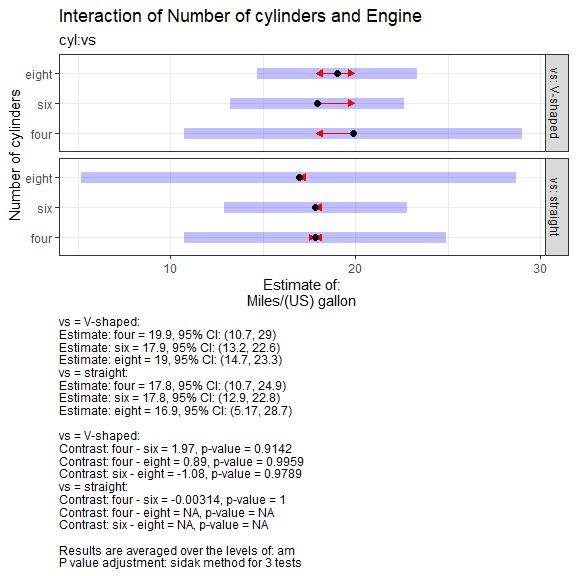

```
#>
#> $`cyl:vs`[[2]]
```

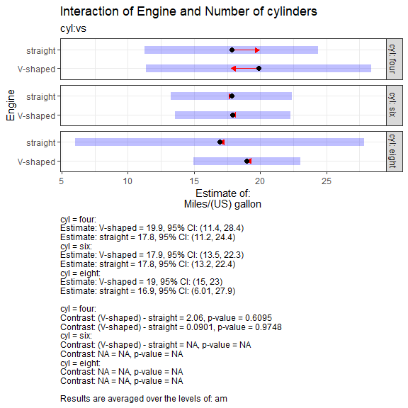

```
#>
#> $`cyl:vs`$both
```

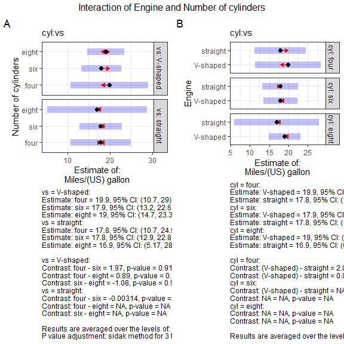

```
#>
#>
#> $`disp:hp`
#> $`disp:hp`[[1]]
```

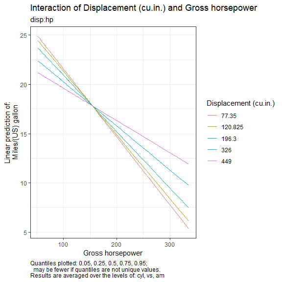

```
#>
#> $`disp:hp`[[2]]
```

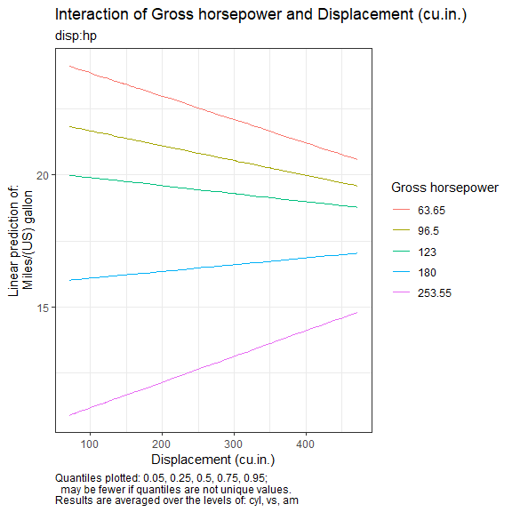

```
#>
#> $`disp:hp`$both
```

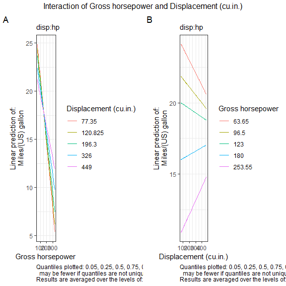

```
#>
#>
#> $`hp:vs`
#> $`hp:vs`[[1]]
```

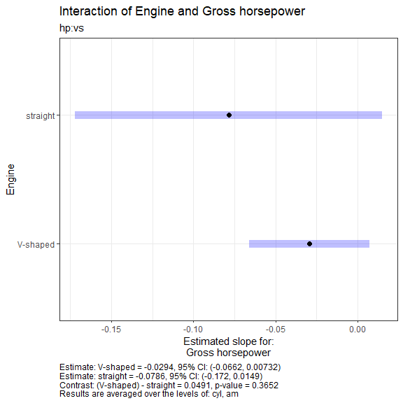

```
#>
#> $`hp:vs`[[2]]
```

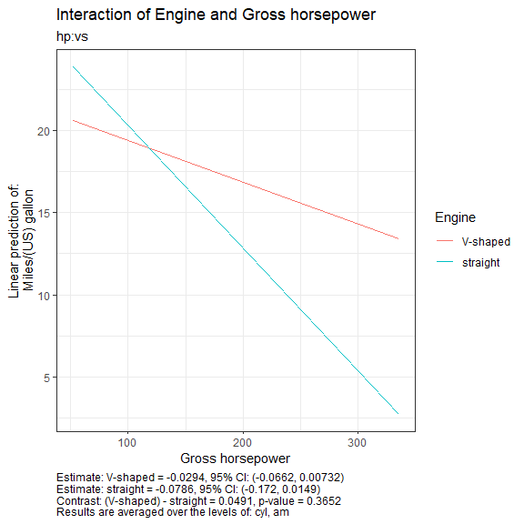

```
#>
#> $`hp:vs`$both
```

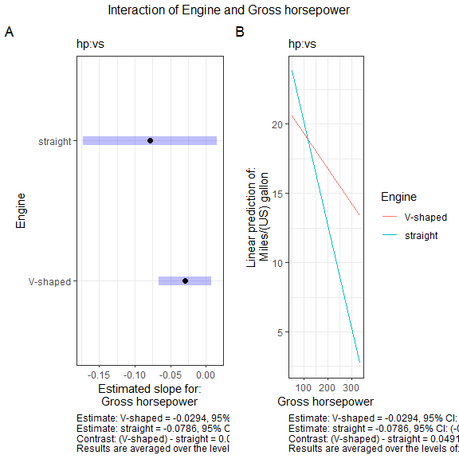

```r
fit_contrasts$plots   # to print plots
```

### 1.3.2 Some options

Below I use some options to specify one two-way interaction, stack them above-below (“tall”), and exclude the table in the plot.

```
#> $`cyl:vs`
#> $`cyl:vs`$both
```

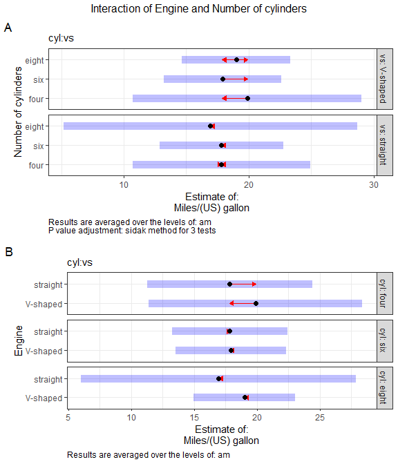

```r
fit_contrasts <-
  e_plot_model_contrasts(
    fit                = fit
  , dat_cont           = dat_mtcars_e
  , choose_contrasts   = "cyl:vs"
  , sw_print           = FALSE
  , sw_table_in_plot   = FALSE
  , sw_TWI_plots_keep  = c("singles", "both", "all")[2]
  , sw_TWI_both_orientation = c("wide", "tall")[2]
  )
fit_contrasts$plots   # to print plots
```

```r
fit_contrasts$tables  # to print tables
```

```
#> $`cyl:vs`
#> $`cyl:vs`$est
#> cyl = four:
#>  vs       emmean   SE df lower.CL upper.CL
#>  V-shaped   19.9 3.53 21    11.39     28.4
#>  straight   17.8 2.73 21    11.24     24.4
#>
#> cyl = six:
#>  vs       emmean   SE df lower.CL upper.CL
#>  V-shaped   17.9 1.82 21    13.54     22.3
#>  straight   17.8 1.91 21    13.23     22.4
#>
#> cyl = eight:
#>  vs       emmean   SE df lower.CL upper.CL
#>  V-shaped   19.0 1.67 21    14.96     23.0
#>  straight   16.9 4.54 21     6.01     27.9
#>
#> Results are averaged over the levels of: am
#> Confidence level used: 0.95
#> Conf-level adjustment: sidak method for 2 estimates
#>
#> $`cyl:vs`$cont
#> cyl = four:
#>  contrast              estimate   SE df t.ratio p.value
#>  (V-shaped) - straight   2.0601 3.97 21   0.519  0.6095
#>
#> cyl = six:
#>  contrast              estimate   SE df t.ratio p.value
#>  (V-shaped) - straight   0.0901 2.82 21   0.032  0.9748
#>
#> cyl = eight:
#>  contrast              estimate   SE df t.ratio p.value
#>  (V-shaped) - straight   nonEst   NA NA      NA      NA
#>
#> Results are averaged over the levels of: am
```

```r
fit_contrasts$text    # to print caption text
```

```
#> $`cyl:vs`
#> $`cyl:vs`[[1]]
#> $`cyl:vs`[[1]][[1]]
#>  [1] "vs = V-shaped:"
#>  [2] "Estimate: four = 19.9, 95% CI: (10.7, 29)"
#>  [3] "Estimate: six = 17.9, 95% CI: (13.2, 22.6)"
#>  [4] "Estimate: eight = 19, 95% CI: (14.7, 23.3)"
#>  [5] "vs = straight:"
#>  [6] "Estimate: four = 17.8, 95% CI: (10.7, 24.9)"
#>  [7] "Estimate: six = 17.8, 95% CI: (12.9, 22.8)"
#>  [8] "Estimate: eight = 16.9, 95% CI: (5.17, 28.7)"
#>  [9] ""
#> [10] "vs = V-shaped:"
#> [11] "Contrast: four - six = 1.97, p-value = 0.9142"
#> [12] "Contrast: four - eight = 0.89, p-value = 0.9959"
```

[output cut: 33 more lines]